## Introduction to the Tidyverse_Datacamp

Description:

- Focused on a powerful set of tools, Tidyverse.
- Learn the intertwined processes of data manipulation and visualization using the tools dplyr and ggplot2.
- Learn to manipulate data by filtering, sorting, and summarizing a real dataset of historical country data in order to answer exploratory questions.
- Learn to turn this processed data into informative line plots, bar plots, histograms, and more with the ggplot2 package.

### 1. Data wrangling

#### a. Filtering in R

**Dataset gapminder**

| country | continent | year | lifeExp | pop | gdpPercap |
| --- | --- | --- | --- | --- | --- |
| Afghanistan | Asia | 1952 | 28.801 | 8425333 | 779.4453 |
| Afghanistan | Asia | 1957 | 30.332 | 9240934 | 820.8530 |
| Afghanistan | Asia | 1962 | 31.997 | 10267083 | 853.1007 |
| Afghanistan | Asia | 1967 | 34.020 | 11537966 | 836.1971 |
| Afghanistan | Asia | 1972 | 36.088 | 13079460 | 739.9811 |

**Filtering 1 year**

| country | continent | year | lifeExp | pop | gdpPercap |
| --- | --- | --- | --- | --- | --- |
| Afghanistan | Asia | 1957 | 30.332 | 9240934 | 820.853 |
| Albania | Europe | 1957 | 59.280 | 1476505 | 1942.284 |
| Algeria | Africa | 1957 | 45.685 | 10270856 | 3013.976 |
| Angola | Africa | 1957 | 31.999 | 4561361 | 3827.940 |
| Argentina | Americas | 1957 | 64.399 | 19610538 | 6856.856 |

**Filtering for one country and one year**

| country | continent | year | lifeExp | pop | gdpPercap |
| --- | --- | --- | --- | --- | --- |
| China | Asia | 2002 | 72.028 | 1280400000 | 3119.281 |

Sort in ascending order of lifeExp

| country | continent | year | lifeExp | pop | gdpPercap |
| --- | --- | --- | --- | --- | --- |
| Rwanda | Africa | 1992 | 23.599 | 7290203 | 737.0686 |
| Afghanistan | Asia | 1952 | 28.801 | 8425333 | 779.4453 |
| Gambia | Africa | 1952 | 30.000 | 284320 | 485.2307 |
| Angola | Africa | 1952 | 30.015 | 4232095 | 3520.6103 |
| Sierra Leone | Africa | 1952 | 30.331 | 2143249 | 879.7877 |

Sort in descending order of lifeExp

| country | continent | year | lifeExp | pop | gdpPercap |
| --- | --- | --- | --- | --- | --- |
| Japan | Asia | 2007 | 82.603 | 127467972 | 31656.07 |
| Hong Kong, China | Asia | 2007 | 82.208 | 6980412 | 39724.98 |
| Japan | Asia | 2002 | 82.000 | 127065841 | 28604.59 |
| Iceland | Europe | 2007 | 81.757 | 301931 | 36180.79 |
| Switzerland | Europe | 2007 | 81.701 | 7554661 | 37506.42 |

Filter for the year 1957, then arrange in descending order of population

| country | continent | year | lifeExp | pop | gdpPercap |
| --- | --- | --- | --- | --- | --- |
| China | Asia | 1957 | 50.54896 | 637408000 | 575.9870 |
| India | Asia | 1957 | 40.24900 | 409000000 | 590.0620 |
| United States | Americas | 1957 | 69.49000 | 171984000 | 14847.1271 |
| Japan | Asia | 1957 | 65.50000 | 91563009 | 4317.6944 |
| Indonesia | Asia | 1957 | 39.91800 | 90124000 | 858.9003 |

Use mutate to create a new column called lifeExpMonths

| country | continent | year | lifeExp | pop | gdpPercap | lifeExpMonths |
| --- | --- | --- | --- | --- | --- | --- |
| Afghanistan | Asia | 1952 | 28.801 | 8425333 | 779.4453 | 345.612 |
| Afghanistan | Asia | 1957 | 30.332 | 9240934 | 820.8530 | 363.984 |
| Afghanistan | Asia | 1962 | 31.997 | 10267083 | 853.1007 | 383.964 |
| Afghanistan | Asia | 1967 | 34.020 | 11537966 | 836.1971 | 408.240 |
| Afghanistan | Asia | 1972 | 36.088 | 13079460 | 739.9811 | 433.056 |

# Filter, mutate, and arrange the gapminder dataset

| country | continent | year | lifeExp | pop | gdpPercap | lifeExpMonths |
| --- | --- | --- | --- | --- | --- | --- |
| Japan | Asia | 2007 | 82.603 | 127467972 | 31656.07 | 991.236 |
| Hong Kong, China | Asia | 2007 | 82.208 | 6980412 | 39724.98 | 986.496 |
| Iceland | Europe | 2007 | 81.757 | 301931 | 36180.79 | 981.084 |
| Switzerland | Europe | 2007 | 81.701 | 7554661 | 37506.42 | 980.412 |
| Australia | Oceania | 2007 | 81.235 | 20434176 | 34435.37 | 974.820 |

### 2. Visualizing with ggplot2

```r
library(ggplot2)
```

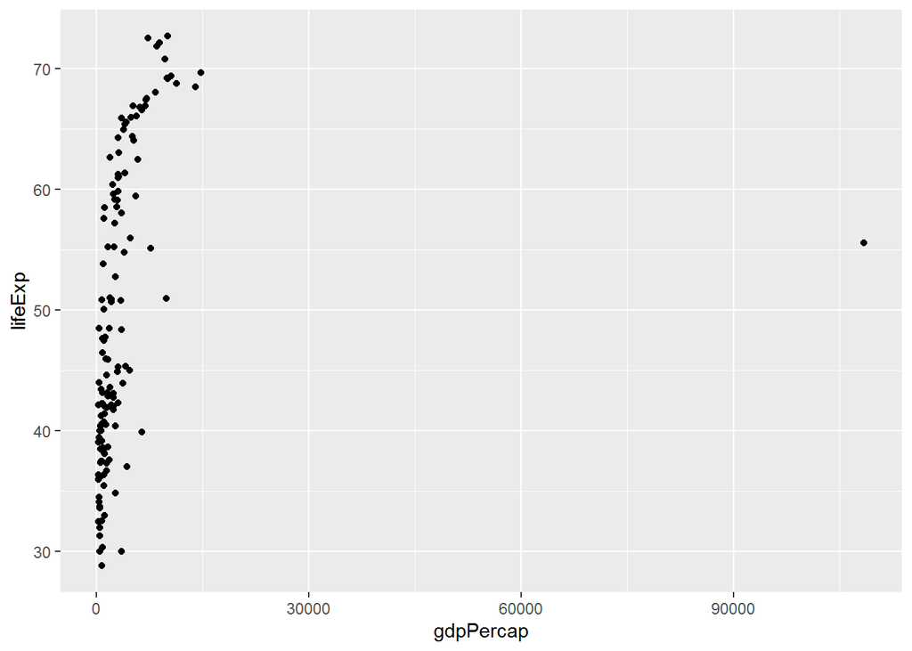

```r
gapminder_1952 <- gapminder %>%
  filter(year == 1952)
ggplot(gapminder_1952, aes(x = gdpPercap, y = lifeExp)) +
  geom_point()
```

Scatterplot for population and dgpPercap

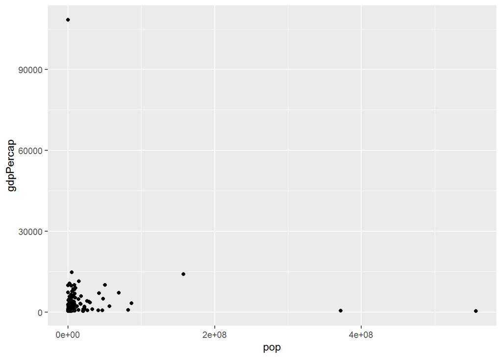

```r
ggplot(gapminder_1952, aes(x = pop, y = gdpPercap)) +
  geom_point()
```

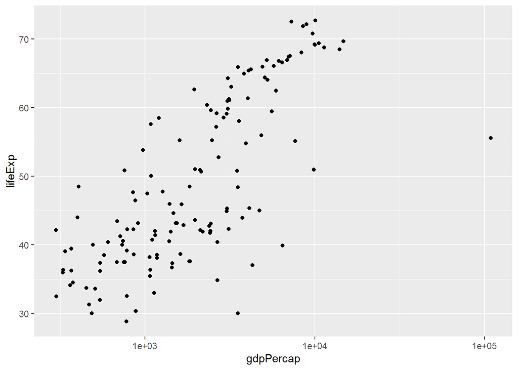

```r
ggplot(gapminder_1952, aes(x = gdpPercap, y = lifeExp)) +
geom_point() + scale_x_log10()
```

Scatter plot comparing pop and gdpPercap, with both axes on a log scale

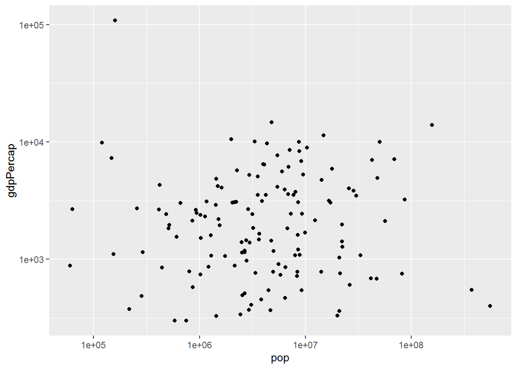

```r
ggplot(gapminder_1952, aes(x=pop, y= gdpPercap))+ geom_point()+ scale_x_log10()+scale_y_log10()
```

# Scatter plot comparing pop and lifeExp, with color representing continent

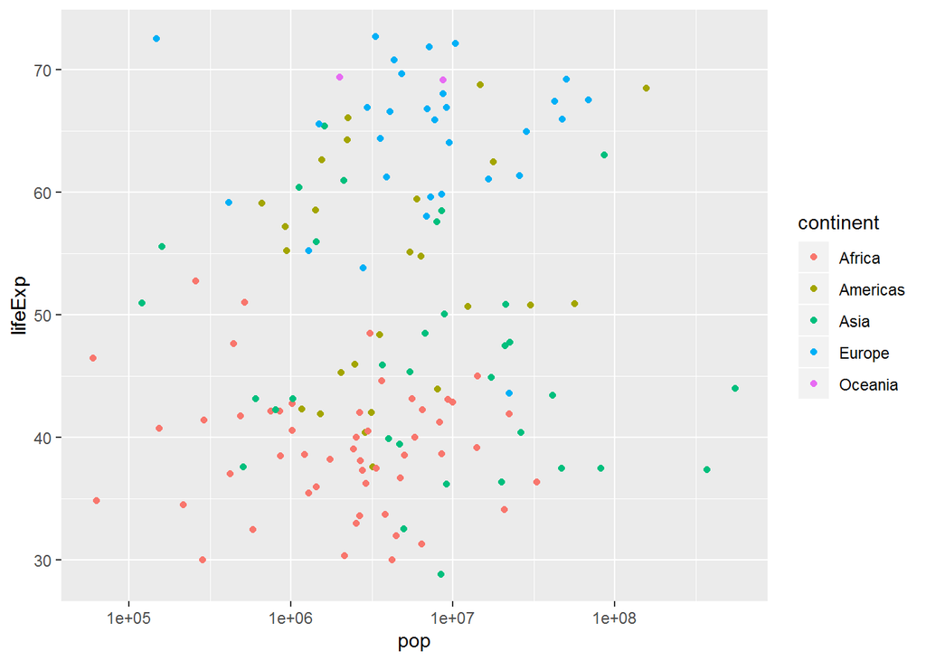

```r
ggplot(gapminder_1952, aes(x=pop, y=lifeExp, color = continent)) +geom_point()+ scale_x_log10()
```

the scatter plot so that the size of the points represents each country’s GDP per capita

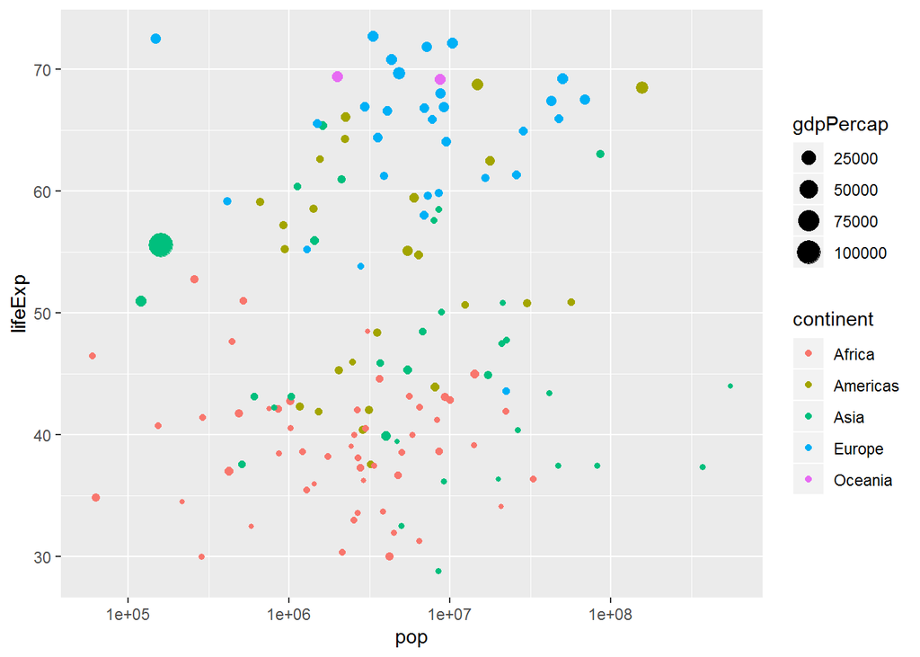

```r
ggplot(gapminder_1952, aes(x = pop, y = lifeExp, color = continent,  size = gdpPercap)) +
  geom_point() +
  scale_x_log10()
```

### Faceting

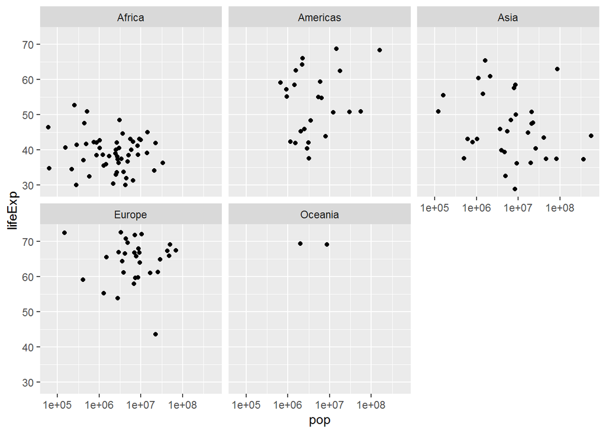

```r
# Scatter plot comparing pop and lifeExp, faceted by continent
ggplot(gapminder_1952, aes(x = pop, y = lifeExp)) +
geom_point() +
scale_x_log10() +
facet_wrap(~ continent)
```

Scatter plot comparing gdpPercap and lifeExp, with color representing continent and size representing population, faceted by year

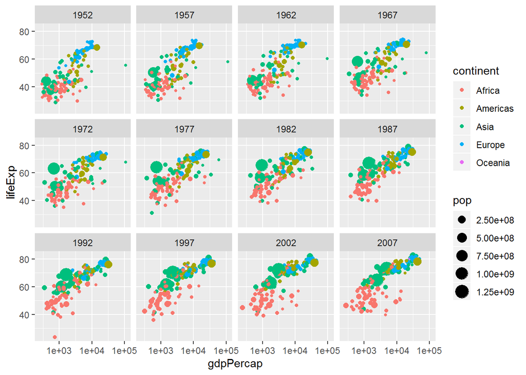

```r
ggplot(gapminder, aes(x=gdpPercap, y=lifeExp, color =continent, size=pop))+geom_point()+scale_x_log10()+facet_wrap(~year)
```

### The summarize verb

Summarize to find the mian life expectancy

```r
gapminder %>%
summarize(meanLifeExp=median(lifeExp))
```

```
## # A tibble: 1 x 1
##   meanLifeExp
##         <dbl>
## 1        60.7
```

Filter for 1957 then summarize the median life expectancy

```r
gapminder %>%
filter(year == 1957) %>%
summarize(medianLifeExp=median(lifeExp))
```

```
## # A tibble: 1 x 1
##   medianLifeExp
##           <dbl>
## 1          48.4
```

Filter for 1957 then summarize the median life expectancy and the maximum GDP per capita

```r
gapminder %>%
filter(year==1957) %>%
summarize(medianLifeExp = median(lifeExp), maxGdpPercap=max(gdpPercap))
```

```
## # A tibble: 1 x 2
##   medianLifeExp maxGdpPercap
##           <dbl>        <dbl>
## 1          48.4      113523.
```

Find median life expectancy and maximum GDP per capita in each year

```r
gapminder %>%
  group_by(year) %>%
    summarize(medianLifeExp =median(lifeExp), maxGdpPercap=max(gdpPercap))
```

```
## # A tibble: 12 x 3
##     year medianLifeExp maxGdpPercap
##    <int>         <dbl>        <dbl>
##  1  1952          45.1      108382.
##  2  1957          48.4      113523.
##  3  1962          50.9       95458.
##  4  1967          53.8       80895.
##  5  1972          56.5      109348.
##  6  1977          59.7       59265.
##  7  1982          62.4       33693.
##  8  1987          65.8       31541.
##  9  1992          67.7       34933.
## 10  1997          69.4       41283.
## 11  2002          70.8       44684.
## 12  2007          71.9       49357.
```

# Find median life expectancy and maximum GDP per capita in each continent in 1957

```r
gapminder %>%
  filter(year==1957) %>%
    group_by(continent)%>%
      summarize(medianLifeExp=median(lifeExp), maxGdpPercap=max(gdpPercap))
```

```
## # A tibble: 5 x 3
##   continent medianLifeExp maxGdpPercap
##   <fct>             <dbl>        <dbl>
## 1 Africa             40.6        5487.
## 2 Americas           56.1       14847.
## 3 Asia               48.3      113523.
## 4 Europe             67.6       17909.
## 5 Oceania            70.3       12247.
```

# Find median life expectancy and maximum GDP per capita in each continent/year combination

```r
gapminder %>%
  group_by(continent, year) %>%
    summarize(medianLifeExp=median(lifeExp), maxGdpPercap=max(gdpPercap))
```

```
## # A tibble: 60 x 4
## # Groups:   continent [5]
##    continent  year medianLifeExp maxGdpPercap
##    <fct>     <int>         <dbl>        <dbl>
##  1 Africa     1952          38.8        4725.
##  2 Africa     1957          40.6        5487.
##  3 Africa     1962          42.6        6757.
##  4 Africa     1967          44.7       18773.
##  5 Africa     1972          47.0       21011.
##  6 Africa     1977          49.3       21951.
##  7 Africa     1982          50.8       17364.
##  8 Africa     1987          51.6       11864.
##  9 Africa     1992          52.4       13522.
## 10 Africa     1997          52.8       14723.
## # ... with 50 more rows
```

# Plot the change in medianGdpPercap in each continent over time

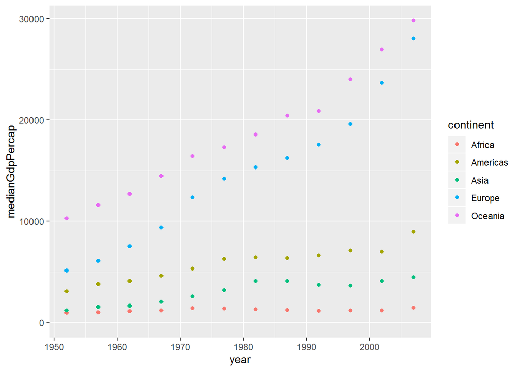

```r
by_year_continent <- gapminder %>%
                      group_by(continent, year) %>%
                        summarize(medianGdpPercap= median(gdpPercap))

ggplot(by_year_continent, aes(x=year, y=medianGdpPercap, color=continent)) +geom_point() + expand_limits(y=0)
```

Use a scatter plot to compare the median GDP and median life expectancy

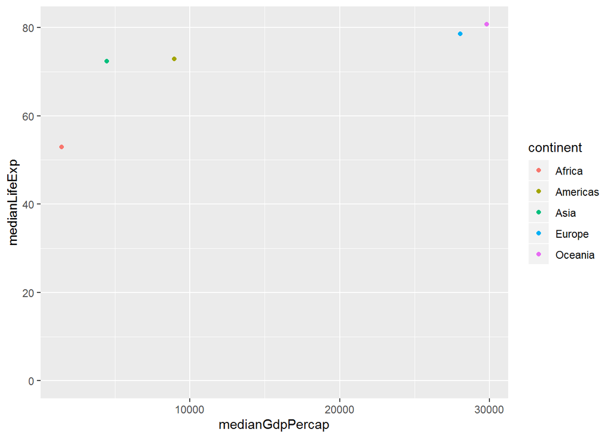

```r
by_continent_2007 <- gapminder %>%
                        filter(year==2007)%>%
                        group_by(continent)%>%
                        summarize(medianLifeExp=median(lifeExp),           medianGdpPercap=median(gdpPercap))

ggplot(by_continent_2007, aes(x=medianGdpPercap, y=medianLifeExp, color=continent))+geom_point()+expand_limits(y=0)
```

### Line plot

Create a line plot showing the change in medianGdpPercap over time

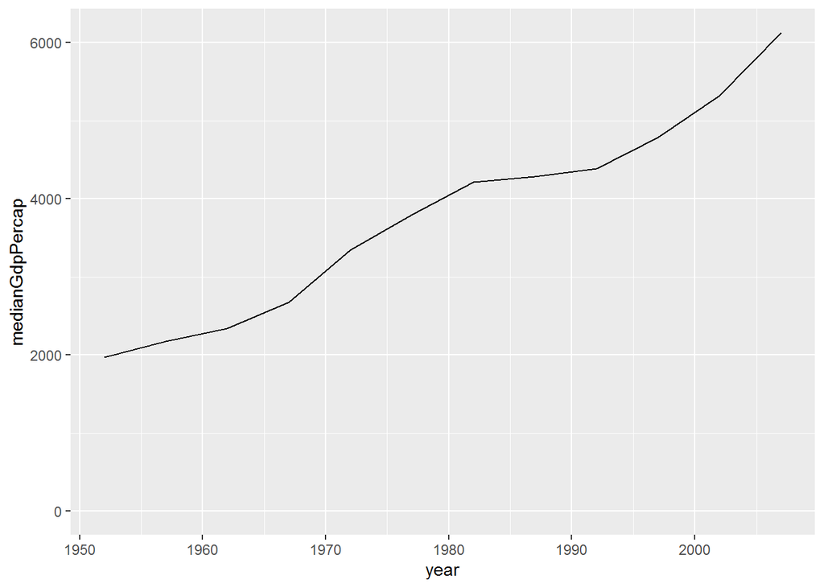

```r
by_year <- gapminder %>%
            group_by(year)%>%
            summarize(medianGdpPercap= median(gdpPercap))

#
ggplot(by_year, aes(x=year, y=medianGdpPercap))+geom_line()+ expand_limits(y=0)
```

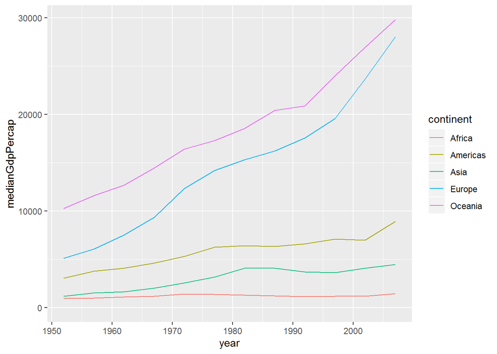

```r
by_year_continent <- gapminder %>%
                      group_by(year, continent) %>%
                      summarize(medianGdpPercap=median(gdpPercap))


# Create a line plot showing the change in medianGdpPercap by continent over time
ggplot(by_year_continent, aes(x=year, y=medianGdpPercap, color =continent)) + geom_line()+expand_limits(y=0)
```

Create a bar plot showing medianGdp by continent

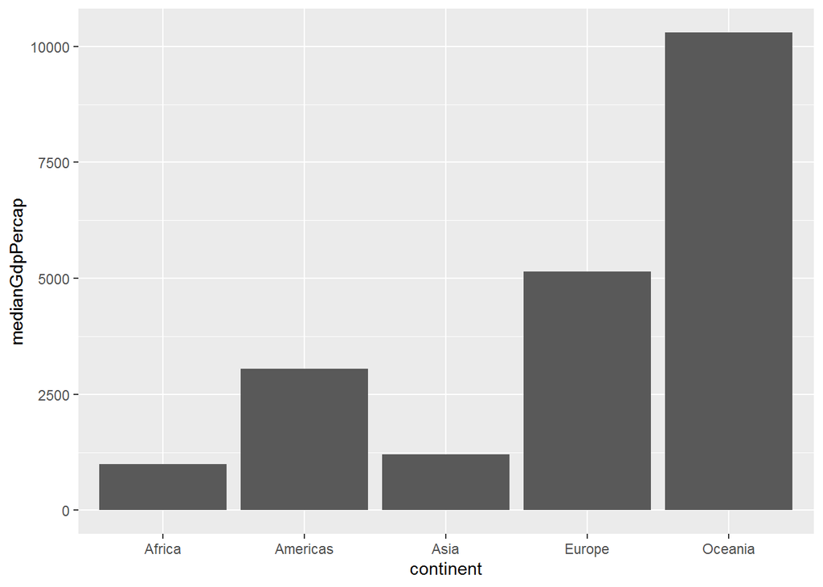

```r
# Summarize the median gdpPercap by continent in 1952
by_continent <- gapminder %>%
                  filter(year==1952)%>%
                  group_by(continent)%>%
                    summarize(medianGdpPercap=median(gdpPercap))

# Create a bar plot showing medianGdp by continent
ggplot(by_continent, aes(x=continent, y=medianGdpPercap)) + geom_col()
```

Create a bar plot of gdpPercap by country

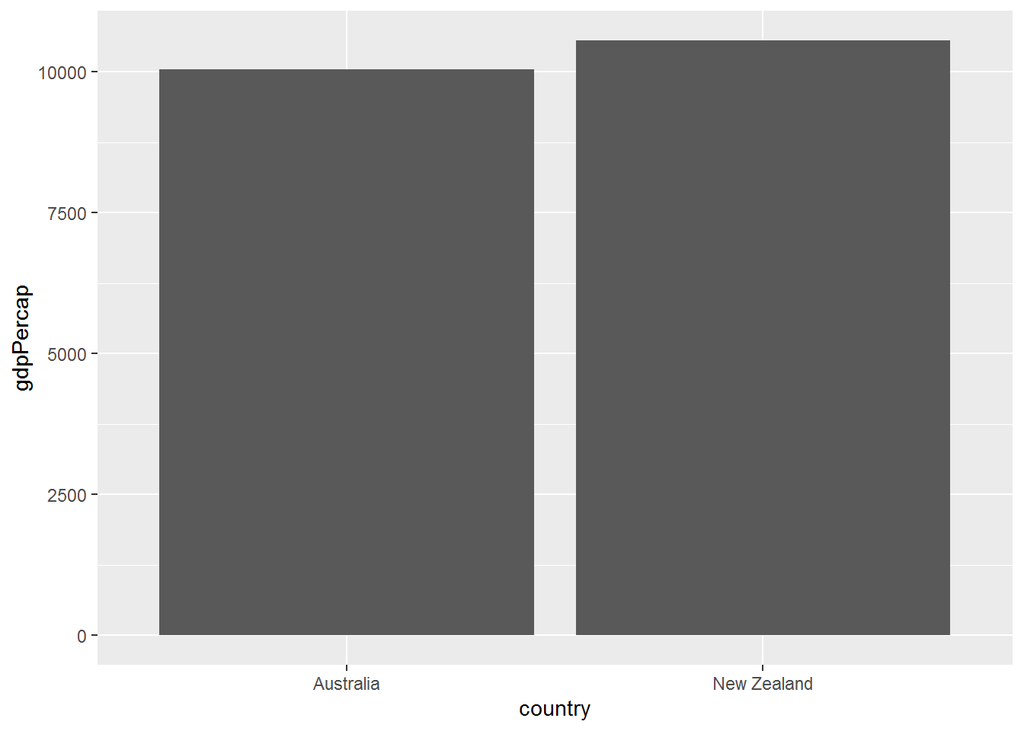

```r
# Filter for observations in the Oceania continent in 1952
oceania_1952 <- gapminder %>%
                  filter(year ==1952, continent == "Oceania")

# Create a bar plot of gdpPercap by country
ggplot(oceania_1952, aes(x=country, y=gdpPercap)) +geom_col()
```

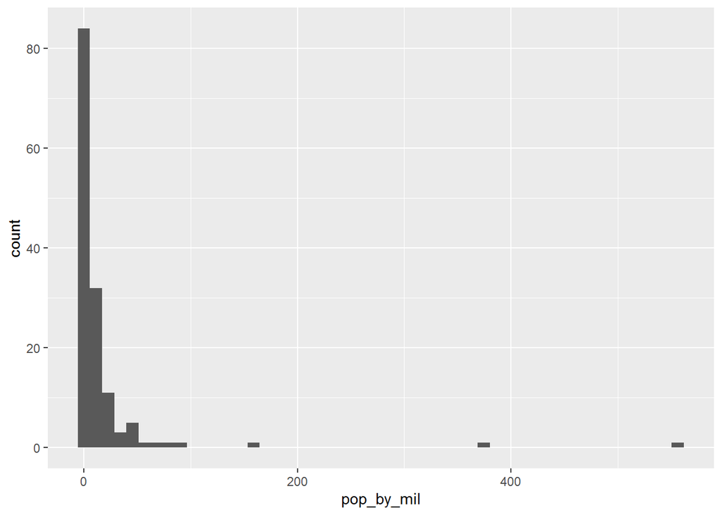

```r
gapminder_1952 <- gapminder %>%
  filter(year == 1952) %>%
  mutate(pop_by_mil = pop / 1000000)

# Create a histogram of population (pop_by_mil)
ggplot(gapminder_1952, aes(x=pop_by_mil))+ geom_histogram(bins=50)
```

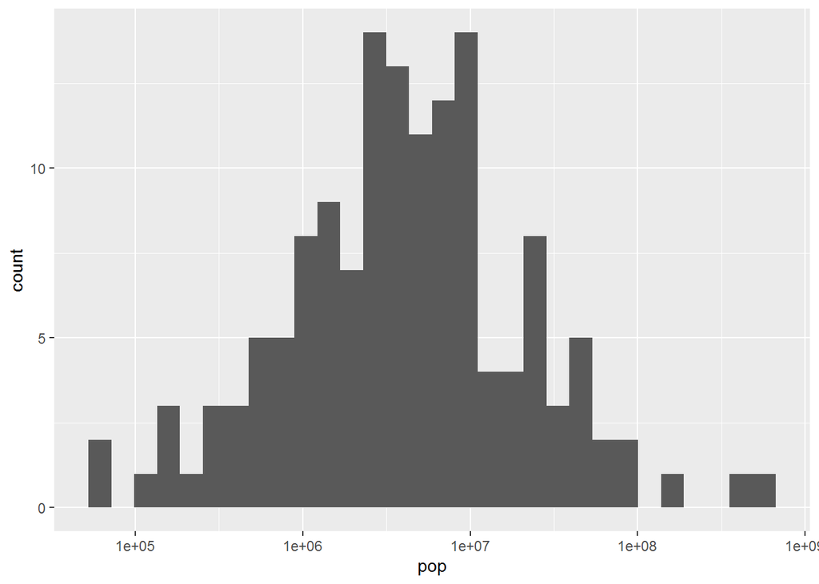

```r
gapminder_1952 <- gapminder %>%
  filter(year == 1952)

# Create a histogram of population (pop), with x on a log scale
ggplot(gapminder_1952, aes(x=pop)) + geom_histogram()+scale_x_log10()
```

Create a boxplot comparing gdpPercap among continents

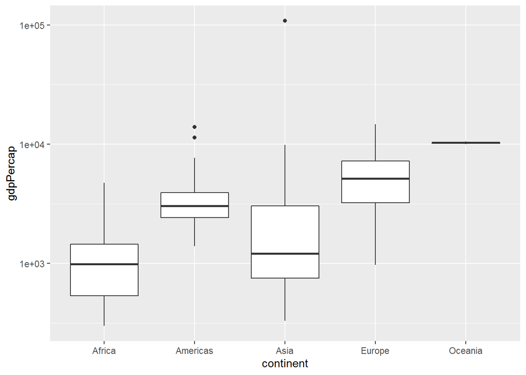

```r
gapminder_1952 <- gapminder %>%
  filter(year == 1952)

# Create a boxplot comparing gdpPercap among continents
ggplot(gapminder_1952, aes(x=continent, y=gdpPercap))+geom_boxplot()+scale_y_log10()
```

# Add a title to this graph: “Comparing GDP per capita across continents”

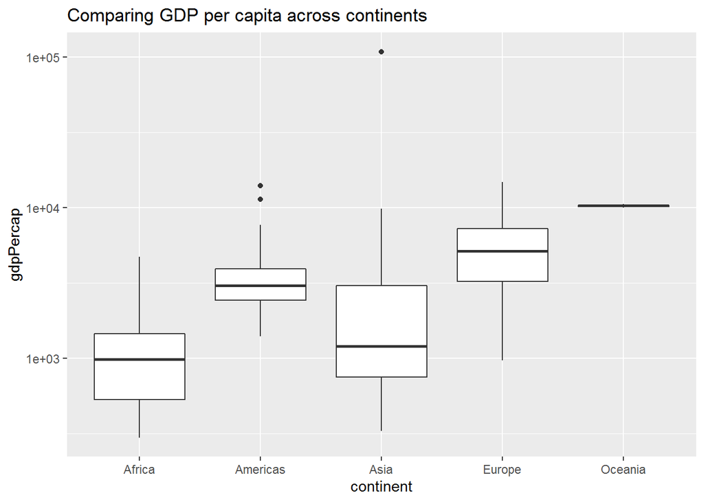

```r
ggplot(gapminder_1952, aes(x = continent, y = gdpPercap)) +
  geom_boxplot() +
  scale_y_log10() +
  ggtitle("Comparing GDP per capita across continents")
```